# **CMSC320 Final Project - Exploring an NFL Dataset**

**Member 1: Ryne Acheson**, Contribution 100%  
**Member 2: Tyler Cariaga**, Contribution 100%

We, all team members, agree together that the above information is true, and we are confident about our contributions to this submitted project/final tutorial.

- Ryne Acheson - May 7, 2024
- Tyler Cariaga - May 7, 2024

### Spring 2024 Data Science Project

Our dataset is comprised of weekly and yearly statistics of every National Football League (NFL) player between 2012 and 2022. The goal of this project is to utilize this data to visualize, analyze, and predict to answer the following questions:

1) **How does the number of years played affect the number of receiving yards by a wide receiver?**  
2) **How do combine measurables such as speed and vertical jump translate to NFL success and draft position?**  
3) **What factors are most important when determining how many yards a running back rushed for? Does age play a large role?**

We chose to explore this dataset due to our shared interest in the NFL and love for data science. We firmly believe that the insights gained throughout this project will benefit us in our data science journey and reveal previously unknown NFL-related trends.

Our data comes from Weekly and Yearly Data on Offensive Players in the NFL from 2012 to 2022

www.kaggle.com/datasets/philiphyde1/nfl-stats-1999-2022/data

### In this tutorial we will be going through the Data Science Lifecycle as following:

- Data Collection / Data Processing
- Exploratory Analysis
- Primary Analysis
- Data Visualization
- Insight and Conclusion

**Group Member Contributions**

Tyler Cariaga: Primarily responsible for Hypothesis 1 and helped with Hypothesis 2, found the dataset.

Ryne Acheson: Primarily responsible for Hypothesis 2 and 3

**Workload was shared equally, as each hypothesis has its own data preprocessing, data exploration, conclusions, visualizations, ML algorithm, etc. Both partners contributed equally to the Final Project Report.**

# **Data Collection / Processing (Data Curation)**

```python
import pandas as pd
import matplotlib.pyplot as plt
from scipy.stats import ttest_ind
from scipy.stats import chi2_contingency
import seaborn as sns
```

```python
import pandas as pd
import matplotlib.pyplot as plt

yearly_df = pd.read_csv('yearly_data_updated_08_23.csv')
weekly_df = pd.read_csv('weekly_data_updated_08_23.csv')

rec_cols = [col for col in yearly_df.columns if 'receiving' in col] + ['total_yards', 'targets']
aggregation = {col: 'sum' for col in rec_cols}

wr_room = yearly_df[yearly_df['position'] == 'WR'][['id', 'name', 'position', 'rookie_season', 'receptions', 'receiving_yards', 'receiving_tds', 'receiving_fumbles', 'receiving_fumbles_lost', 'receiving_air_yards', 'receiving_yards_after_catch', 'receiving_first_downs', 'receiving_2pt_conversions', 'years_played' ]]
for col in wr_room.columns.difference(rec_cols):
    aggregation[col] = 'first'
wr_room['years_played'] = wr_room.groupby('name')['years_played'].transform(max)
wr_room = wr_room.drop_duplicates(subset = 'name')


qb_room = yearly_df[yearly_df['position'] == 'QB'][['id', 'name', 'position', 'rookie_season', 'years_played', 'passing_yards', 'forty', "pass_ypg"]]
qb_room['years_played'] = qb_room.groupby('name')['years_played'].transform(max)
qb_room = qb_room.drop_duplicates(subset = 'name')


rb_room = yearly_df[yearly_df['position'] == 'RB'][['id', 'name', 'position', 'rookie_season', 'years_played', "rushing_yards", "rush_ypg"]]
rb_room['years_played'] = rb_room.groupby('name')['years_played'].transform(max)


te_room = yearly_df[yearly_df['position'] == 'TE'][['id', 'name', 'position', 'rookie_season', 'receptions', 'receiving_yards', 'receiving_tds', 'receiving_fumbles', 'receiving_fumbles_lost', 'receiving_air_yards', 'receiving_yards_after_catch', 'receiving_first_downs', 'receiving_2pt_conversions', 'years_played' ]]
for col in te_room.columns.difference(rec_cols):
    aggregation[col] = 'first'
te_room['years_played'] = te_room.groupby('name')['years_played'].transform(max)
te_room = te_room.drop_duplicates(subset = 'name')
```

We are dealing with statistics from football players, tracking different kinds of performance metrics across several positions like wide receiver (WR), quarterback (QB), running back (RB), and tight end (TE). In football, each position plays a different role and the statistics reflect their contributions to the game:

1. **Wide Receiver (WR)**: Wide receivers catch passes and aims to gain as many yards as possible. Their key stats include receptions (catches made), yards gained after the catch, and touchdowns scored through receptions.
2. **Quarterback (QB)**: Quarterbacks throw passes and directs the offense. Important stats include passing yards (how far the ball is thrown and successfully caught) and passing efficiency.
3. **Running Back (RB)**: Runningbacks primarily run the ball, trying to avoid defenders and gain as many yards possible. Their statistics focus on yards gained from running and their efficiency per game.
4. **Tight End (TE)**: Tight Ends are a hybrid position that both block for the offense and catches passes, much like a wide receiver but typically in shorter distances and often in more crowded areas of the field. Here, their stat types match receivers since we do not have blocking stats at the moment.

Now, let's break down how we organized the data for the players:

- **Load Data**: We begin by loading two sets of data for the players yearly and weekly stats. Think of these as detailed records of what each player achieved either over entire years or specific weeks within a season.
- **Filtering and Processing Data**: We processes this data separately for each player position. We split up players by their position and extract the most important statistics for that position. We then combine data for players who may appear multiple times in the data set to give an organized view of their career stats.
- **Grouping and Transforming**: For each respective dataset, we group by name and years played in order to find duplicate players and determine which data can be used. We calculated the maximum years played so we can find the most recent data on each player. Using the most recent data for each player allows us to not confuse information and can accurately analyse their information. We calculated the maximum years played so we can find the most recent data on each player.
  - **Dropping Duplicates**: Since a player might appear multiple times if they played across multiple years, the code removes duplicate entries to ensure each player is only represented once.
  - **Aggregation**: This is like creating a summary by adding up certain stats, ensuring that if a player's data is split across multiple records, their total contribution is accurately reflected.

We set up a clean, organized database of player statistics that could be used for analysis. Each position type has their most important statistics placed in their respective dataset (`[position]_room`). We can use their position rooms to more easily analyze players and positions.

**Check for Null Values**

```python
nullVals = yearly_df.isnull().sum()
print(f"Nulls: {nullVals}")
```

```
Nulls: id                 0
name               0
position           0
team               0
season             0
                ...
ht              4444
wt              4444
forty           4444
vertical        4444
years_played    4444
Length: 71, dtype: int64
```

# Hypothesis #1

## **Exploratory Analysis**

H0: The years played by a top 10 wide receiver does not have an effect on their receiving yards

HA: The years played by a top 10 wide receiver does have an effect on their receiving yards

```python
most_rec_wr = wr_room[['id', 'name', 'receiving_yards', 'years_played']]
most_rec_wr.loc[872, 'years_played'] = 9
most_rec_wr.loc[652, 'years_played'] = 13
most_rec_wr.loc[1811, 'years_played'] = 10
most_rec_wr.loc[6048, 'years_played'] = 12
most_rec_wr = most_rec_wr.sort_values(by = 'receiving_yards', ascending=False).head(10)
print(most_rec_wr)
```

```
        id              name  receiving_yards  years_played
872    233    Calvin Johnson             1964           9.0
256     57     Andre Johnson             1598          12.0
5423  1548      Stefon Diggs             1535           5.0
652    172  Brandon Marshall             1508          13.0
0        1        A.J. Brown             1496           3.0
2588   734     Ja'Marr Chase             1455           2.0
1811   498  Demaryius Thomas             1434          10.0
1720   476   DeAndre Hopkins             1407           7.0
3469   995  Justin Jefferson             1400           3.0
6048  1732   Vincent Jackson             1384          12.0
```

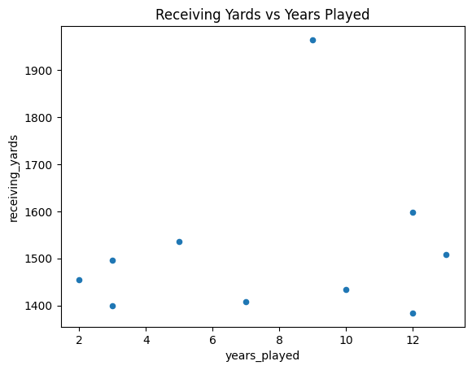

```python
most_rec_wr.plot(kind = 'scatter', x= 'years_played', y= 'receiving_yards', title = 'Receiving Yards vs Years Played')
```

- **Feature Representation**: From the data displayed, there doesn't appear to be an over-representation of any particular feature. Each feature uniquely contributes to describing a player's career in terms of identity, performance, and experience.
- **Feature Correlation**: You might expect some correlation between `receiving_yards` and `years_played` because players who have longer careers could potentially accumulate more yards. However, the actual correlation needs to be statistically tested; high-performing players might accumulate significant yards in shorter careers as well.
- **Outliers**: Calvin Johnson has the most yards by nearly 400 yards, and is in the middle of the pack when it comes to years played. Based on the other data provided, this means he is an outlier. He is an efficient player who ended his career early. (Could be due to injury or other reasons, more research is necessary to find out)

```python
table = pd.crosstab(most_rec_wr['receiving_yards'], most_rec_wr['years_played'])
_, p, _, _ = chi2_contingency(table)
print(f"P-Value: {p}")
```

```
P-Value: 0.25436730515271955
```

**Analysis**: We do not reject the null hypothesis because the p-value is greater than the alpha value of 0.05. The years played by a top 10 wide receiver does not have an effect on their receiving yards.

### **What is a P-Value?**

The p-value is a numerical valuation that shows how strong the evidence is against the null hypothesis provided by the sample data. In layman's terms, the p-value is a tool for making informed judgements about the validaty of a hypothesis. It should be known that the p-value is not an end-all be-all statistic, and its interpretation requires careful thought about the context and limitations of the study.

## **Primary Analysis**

**Apply Machine Learning Algorithms to Determine the Effect of a Top 10 Wide Receiver's Years Played on their Receiving Yards**

We will utilize the following attributes to create a predictive model that will determine the relationship between the years played and receiving yards of a top 10 wide receiver

1) Receiving Yards (Yards)  
2) Years Played (Years)

We will utilize a regression model.

Regression models would be best for this situation because of the following:

- It can be used to predict outcomes. For example, if you know the number of years a wide receiver has played, you can predict their receiving yards based on the regression model.
- Allows us to quantify the strength and form of the relationship between the years played and receiving yards. It not only shows whether more years played is associated with more receiving yards but also how much of a change in receiving yards is expected with each additional year played.
- It offers various metrics (like R-squared, adjusted R-squared, F-statistics) to evaluate how well your model fits the data. This helps in understanding the proportion of variance in the dependent variable explained by the independent variables.

Linear Regression

```python
import pandas as pd
from sklearn.model_selection import train_test_split
from sklearn.linear_model import LinearRegression
from sklearn.metrics import mean_squared_error, r2_score

X = most_rec_wr[['years_played']]
y = most_rec_wr['receiving_yards']

X_train, X_test, y_train, y_test = train_test_split(X, y, test_size=0.2, random_state=0)

model = LinearRegression()

model.fit(X_train, y_train)

y_pred = model.predict(X_test)

print('Mean squared error (MSE):', mean_squared_error(y_test, y_pred))
print('Coefficient of determination (R²):', r2_score(y_test, y_pred))
```

```
Mean squared error (MSE): 5771.918654259605
Coefficient of determination (R²): -0.26681342205972136
```

Robust Regression

```python
import pandas as pd
from sklearn.linear_model import RANSACRegressor
from sklearn.linear_model import LinearRegression
from sklearn.model_selection import train_test_split
from sklearn.metrics import mean_squared_error, r2_score

X = most_rec_wr[['years_played']]
y = most_rec_wr['receiving_yards']

X_train, X_test, y_train, y_test = train_test_split(X, y, test_size=0.2, random_state=42)

model = RANSACRegressor(estimator=LinearRegression(), min_samples=0.5, max_trials=100, loss='absolute_error', random_state=0)
model.fit(X_train, y_train)

y_pred = model.predict(X_test)

print('Mean squared error (MSE):', mean_squared_error(y_test, y_pred))
print('Coefficient of determination (R²):', r2_score(y_test, y_pred))
```

```
Mean squared error (MSE): 23101.04648760328
Coefficient of determination (R²): -1.3570091304564103
```

Polynomial Regression

```python
import numpy as np
import matplotlib.pyplot as plt
from sklearn.preprocessing import PolynomialFeatures
from sklearn.linear_model import LinearRegression
from sklearn.pipeline import make_pipeline
from sklearn.metrics import mean_squared_error, r2_score

degree = 2
polyreg = make_pipeline(PolynomialFeatures(degree), LinearRegression())

X_train_np = X_train.values.reshape(-1, 1)
y_train_np = y_train.values
X_test_np = X_test.values.reshape(-1, 1)
y_test_np = y_test.values

polyreg.fit(X_train_np, y_train_np)
y_pred = polyreg.predict(X_test_np)

print('Mean squared error (MSE):', mean_squared_error(y_test_np, y_pred))
print('Coefficient of determination (R²):', r2_score(y_test_np, y_pred))
```

```
Mean squared error (MSE): 8374.194296091791
Coefficient of determination (R²): 0.14557756391268328
```

### **Model Chosen**

- Polynomial Regression Model

## **Visualization**

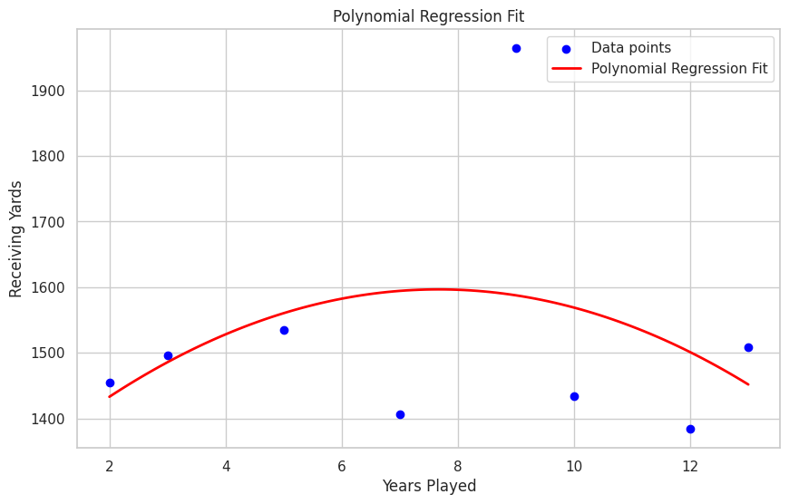

```python
X_fit = np.linspace(X_train.min(), X_train.max(), 100).reshape(-1, 1)
y_pred = polyreg.predict(X_fit)
plt.figure(figsize=(10, 6))
plt.scatter(X_train_np, y_train_np, color='blue', label='Data points')
plt.plot(X_fit, y_pred, color='red', linewidth=2, label='Polynomial Regression Fit')
plt.xlabel('Years Played')
plt.ylabel('Receiving Yards')
plt.title('Polynomial Regression Fit')
plt.legend()
plt.show()
```

## **Conclusion and Insight**

There does not seem to be a strong correlation between years played and receiving yards within the top 10 wide receivers in the NFL. Calvin Johnson had the most receiving yards by nearly 400 yards while having the 5th most years played within the group. It is possible that injury or personal issues can skew the data since it could cause players to end their careers early. Some of the players in the top 10 are currently playing in the NFL, so it is possible that the years played will have an effect on receiving yards when those players finish their careers. There are many outside variables that effect this data relationship.

The p-value is greater than 0.05 which supports the conclusion that the years played by a top 10 wide receiver does not have an effect on their receiving yards.

# Hypothesis #1 B

The version of Hypothesis 1 above struggled to find a correlation between years played and receiving yards. We believe this is because there were not enough data points to find a pattern and teach a ML model. Hypothesis 1B will travel through the same process , but with more data points(players).

## **Exploratory Analysis**

H0: The years played by a wide receiver does not have an effect on their receiving yards

HA: The years played by a wide receiver does have an effect on their receiving yards

```python
all_rec_wr = wr_room[['id', 'name', 'receiving_yards', 'years_played']]
all_rec_wr.loc[872, 'years_played'] = 9
all_rec_wr.loc[652, 'years_played'] = 13
all_rec_wr.loc[1811, 'years_played'] = 10
all_rec_wr.loc[6048, 'years_played'] = 12
all_rec_wr = all_rec_wr.dropna(subset=['receiving_yards', 'years_played'])
all_rec_wr = all_rec_wr.sort_values(by = 'receiving_yards', ascending=False)
print(all_rec_wr)
```

```
        id              name  receiving_yards  years_played
872    233    Calvin Johnson             1964           9.0
256     57     Andre Johnson             1598          12.0
5423  1548      Stefon Diggs             1535           5.0
652    172  Brandon Marshall             1508          13.0
0        1        A.J. Brown             1496           3.0
...    ...               ...              ...           ...
3104   888          Joe Reed                0           1.0
3147   901         John Ross                0           4.0
2383   661      Geremy Davis                0           1.0
4215  1210     Marvin McNutt                0           1.0
3702  1073     Kevin Norwood                0           1.0

[248 rows x 4 columns]
```

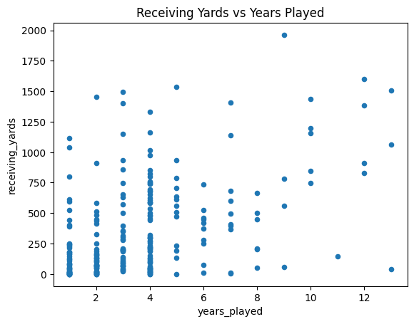

```python
all_rec_wr.plot(kind = 'scatter', x= 'years_played', y= 'receiving_yards', title = 'Receiving Yards vs Years Played')
```

- **Feature Correlation**: You might expect some correlation between `receiving_yards` and `years_played` because players who have longer careers have more opportunity to acquire a high yardage season. However, the actual correlation needs to be statistically tested. High performing players may accumulate significant yards in shorter careers as well.
- **Outliers**: The data points are quite spread out vertically at nearly all levels of years played.

```python
table = pd.crosstab(all_rec_wr['receiving_yards'], all_rec_wr['years_played'])
_, p, _, _ = chi2_contingency(table)
print(f"P-Value: {p}")
```

```
P-Value: 0.0008251816952324482
```

**Analysis**: We can reject the null hypothesis because the p-value is less than the alpha value of 0.05. The years played by a wide receiver has an effect on their receiving yards.

## **Primary Analysis**

**Apply Machine Learning Algorithms to Determine the Effect of the Number of Years Played on a Wide Receiver's Receiving Yards**

Similar to the first part, we will utilize the following attributes to create a predictive model that will determine the relationship between the years played and receiving yards of a wide receiver

1) Receiving Yards (Yards)  
2) Years Played (Years)

We will utilize a regression model.

Regression models would be best for this situation because of the following:

- It can be used to predict outcomes. For example, if you know the number of years a wide receiver has played, you can predict their receiving yards based on the regression model.
- Allows us to quantify the strength and form of the relationship between the years played and receiving yards. It not only shows whether more years played is associated with more receiving yards but also how much of a change in receiving yards is expected with each additional year played.
- It offers various metrics (like R-squared, adjusted R-squared, F-statistics) to evaluate how well your model fits the data. This helps in understanding the proportion of variance in the dependent variable explained by the independent variables.

Linear Regression

```python
import pandas as pd
from sklearn.model_selection import train_test_split
from sklearn.linear_model import LinearRegression
from sklearn.metrics import mean_squared_error, r2_score

X = all_rec_wr[['years_played']]
y = all_rec_wr['receiving_yards']

X_train, X_test, y_train, y_test = train_test_split(X, y, test_size=0.2, random_state=42)

model = LinearRegression()

model.fit(X_train, y_train)

y_pred = model.predict(X_test)

print('Mean squared error (MSE):', mean_squared_error(y_test, y_pred))
print('Coefficient of determination (R²):', r2_score(y_test, y_pred))
```

```
Mean squared error (MSE): 135070.7508366913
Coefficient of determination (R²): 0.2482208193666301
```

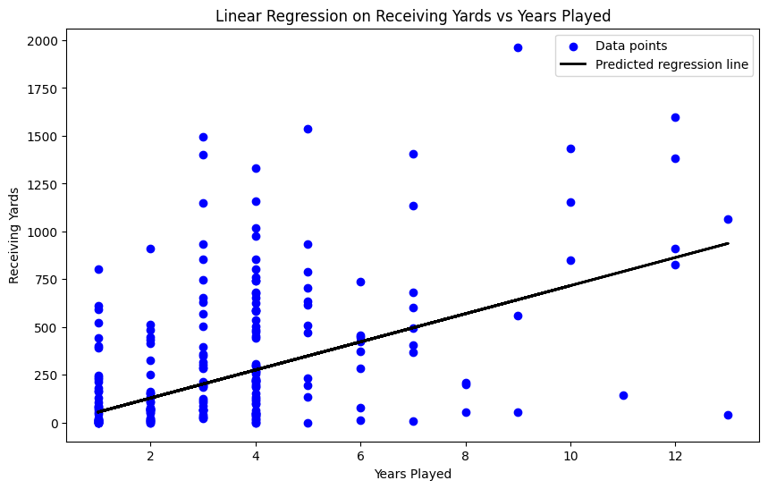

```python
plt.figure(figsize=(10, 6))
plt.scatter(X_train, y_train, color='blue', label='Data points')
plt.plot(X_test, y_pred, color='black', linewidth=2, label='Predicted regression line')
plt.xlabel('Years Played')
plt.ylabel('Receiving Yards')
plt.title('Linear Regression on Receiving Yards vs Years Played')
plt.legend()
plt.show()
```

- **Fit of Regression Line**: The regression line appears to be capturing a general upward trend, meaning as years played increases, the receiving yards also tend to increase.
- **Coefficient of Determination (R²)**: The model outputs an R² value of about 0.24. This value indicates that approximately 24% of the variability in the receiving yards is explained by the years played according to your model.
- **Mean Squared Error (MSE)**: The MSE is quite high, which suggests that the model's predictions deviate substantially on average from the actual values.

Robust Regression

```python
import pandas as pd
from sklearn.linear_model import RANSACRegressor
from sklearn.linear_model import LinearRegression
from sklearn.model_selection import train_test_split
from sklearn.metrics import mean_squared_error, r2_score

X = all_rec_wr[['years_played']]
y = all_rec_wr['receiving_yards']

X_train, X_test, y_train, y_test = train_test_split(X, y, test_size=0.2, random_state=40)

model = RANSACRegressor(estimator=LinearRegression(), min_samples=0.5, max_trials=100, loss='absolute_error', random_state=0)
model.fit(X_train, y_train)

y_pred = model.predict(X_test)

print('Mean squared error (MSE):', mean_squared_error(y_test, y_pred))
print('Coefficient of determination (R²):', r2_score(y_test, y_pred))
```

```
Mean squared error (MSE): 125766.28161559747
Coefficient of determination (R²): 0.18072270297423876
```

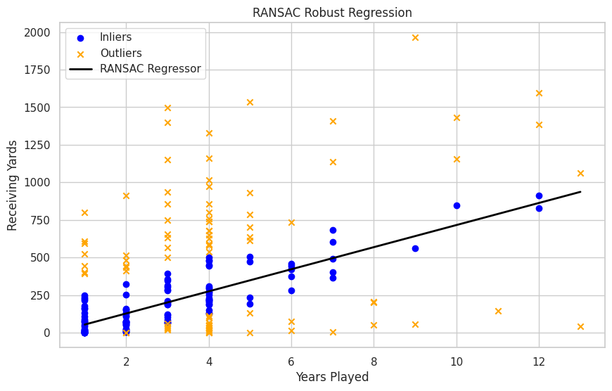

```python
import matplotlib.pyplot as plt
import numpy as np

X_train_np = X_train.values.reshape(-1, 1)
y_train_np = y_train.values

inlier_mask = model.inlier_mask_
outlier_mask = np.logical_not(inlier_mask)

plt.figure(figsize=(10, 6))
plt.scatter(X_train_np[inlier_mask], y_train_np[inlier_mask], color='blue', marker='o', label='Inliers')
plt.scatter(X_train_np[outlier_mask], y_train_np[outlier_mask], color='orange', marker='x', label='Outliers')

line_X = np.linspace(X_train_np.min(), X_train_np.max(), num=250).reshape(-1, 1)
line_y_ransac = model.predict(line_X)

plt.plot(line_X, line_y_ransac, color='black', linewidth=2, label='RANSAC Regressor')

plt.xlabel('Years Played')
plt.ylabel('Receiving Yards')
plt.title('RANSAC Robust Regression')
plt.legend(loc='upper left')
plt.show()
```

- **Fit of Regression Line**: The regression line appears to be capturing a general upward trend, meaning as years played increases, the receiving yards also tend to increase.
- **Coefficient of Determination (R²)**: The model outputs an R² value of about 0.18. This value indicates that approximately 18% of the variability in the receiving yards is explained by the years played according to your model. This is a substantially low R² value.
- **Mean Squared Error (MSE)**: The MSE is quite high, which suggests that the model's predictions deviate substantially on average from the actual values. Although lower than linear regression, it is a negligible difference.

### **Model Chosen**

- Linear Regression Model

The linear regression model contained a slightly higher mean squared error and a higher R² than the robust regression model. The difference in R² is more significant than the mean squared error so the linear regression model is found to be better for our data.

## **Conclusion and Insight**

Overall, with more data points that we can use, the plot and the accompanying metrics suggest that there is a positive correlation between years played and receiving yards. The relationship is not strong enough for the model to make highly accurate predictions, but we know a correlation exists. The model produced a high error metric, combined with a low R², implies that the model may not be very effective at predicting the receiving yards based solely on years played. It's likely that other factors also play significant roles in determining receiving yards, which are not included in this model. Data that is not readily available in our dataset, like injury, could have a significant effect on the performance of a wide receiver. We have found one variable that effects receiving yards, years played, but there are likely more variables that go into the relationship.

The p-value is less than 0.05 which supports the conclusion that the years played by a wide receiver does have an effect on their receiving yards.

# Hypothesis #2

H0: Fast quarterbacks (40 time of 4.7 or less) and slow quarterbacks (40 time of 4.71 or more) do share similar passing yards per game averages

HA: Fast quarterbacks (40 time of 4.7 or less) and slow quarterbacks (40 time of 4.71 or more) do not share similar passing yards per game averages

```python
updated_qb_room = qb_room[qb_room["forty"].notna()]

slow_qbs = updated_qb_room[updated_qb_room["forty"] >= 4.71]
fast_qbs = updated_qb_room[updated_qb_room["forty"] <= 4.70]

from scipy.stats import ttest_ind
_, p = ttest_ind(fast_qbs["pass_ypg"], slow_qbs["pass_ypg"])
print(f"P-value:", p)

# Since the p-value (0.958) is greater than the alpha (0.05) we fail to reject
# the null hypothesis (that fast quarterbacks and slow quarterbacks share
# similar passing yards per game)
```

```
P-value: 0.9581132366172036
```

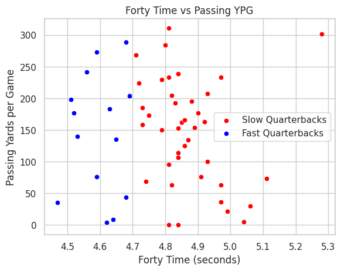

```python
# Visualize the data (I've used seaborn in the past and I am more familiar with
# graphing using seaborn so I decided to utilize it instead of matplotlib)
import seaborn as sns

sns.scatterplot(x="forty", y="pass_ypg", data=slow_qbs, color='red', label='Slow Quarterbacks')
sns.scatterplot(x="forty", y="pass_ypg", data=fast_qbs, color='blue', label='Fast Quarterbacks')

plt.title('Forty Time vs Passing YPG')
plt.xlabel('Forty Time (seconds)')
plt.ylabel('Passing Yards per Game')
```

**Apply Machine Learning Algorithms to Determine the Draft Position of a Player based on Athleticism and Physical Attributes**

We will utilize the following attributes to create a predictive model that will determine the round a player is drafted in  
1) Weight (Pounds)  
2) 40-yard Dash Time (Seconds)  
3) Vertical Jump (Inches)

**Prediction**: Physical attributes are a generally good hueristics to determine a player's draft position. Typically players that are faster and jump higher get drafted in earlier rounds. I estimate that the better model of the two will be accurate about 70% of the time.

**What is a Random Forest Classifier?**

A Random Forest Classifier is an ensemble machine learning algorithm that is made up of many decision trees that takes the most frequent classification of the many decision trees. Decision Trees can be too simple and are prone to overfitting hence why a random forest can be better.

**Why use a Random Forest Classifier in this scenario?**

There are many data points making it a relatively complex dataset. In this case since there is relatively low dimensionality, a random forest makes the model less prone to overfitting. Futhermore in the real world there are outliers in terms of athletic freaks and a random forest classifier is more robust towards outliers such as these. It is also a ML algorithm that is straightforward and easy to understand

```python
from sklearn.ensemble import RandomForestClassifier
from sklearn.model_selection import train_test_split
from sklearn.metrics import accuracy_score

# Ensure that all draft round entries are a valid number between 1 and 7
# inclusive as there are 7 rounds in the modern NFL draft.
print(yearly_df["round"].value_counts())

# Drop all entries with NaN for round, weight, forty time, or vertical jump
data = yearly_df.dropna(subset = ["round", "wt", "forty", "vertical"])

print(f"Observe that after dropping NaN entries, {len(data)} remain")

X = data[["wt", "forty", "vertical"]]
y = data["round"]

# Split the data into training and testing sets
X_train, X_test, y_train, y_test = train_test_split(X, y, test_size=0.2, random_state=42)

# Initialize and train the Random Forest
model = RandomForestClassifier(n_estimators=100, random_state=42)
model.fit(X_train, y_train)

# Predict on the testing set
pred = model.predict(X_test)

accuracy = accuracy_score(y_test, pred)
print(f"Random Forest Classifier Accuracy: {accuracy:.2%}")
```

```
round
1.0    364
2.0    332
3.0    304
4.0    291
5.0    190
6.0    152
7.0    104
Name: count, dtype: int64
Observe that after dropping NaN entries, 1737 remain
Random Forest Classifier Accuracy: 89.66%
```

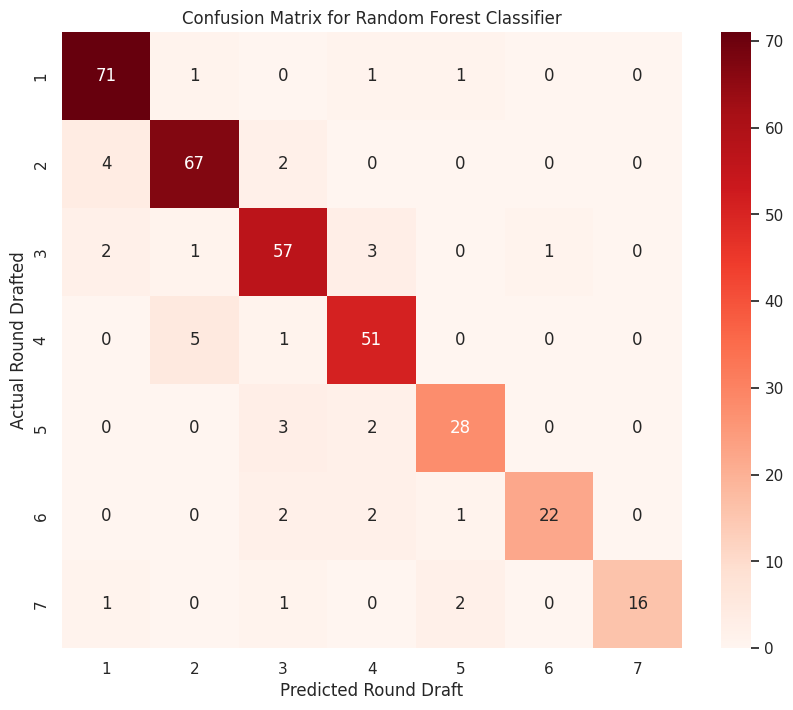

```python
import seaborn as sns
import matplotlib.pyplot as plt
from sklearn.metrics import confusion_matrix

# Create a confusion matrix
cm = confusion_matrix(y_test, pred)

# Plot the confusion matrix and utilize a heat map
plt.figure(figsize=(10, 8))

# Create custom labels ranging from 1 to 7 inclusive
labels = [str(i) for i in range(1, 8)]
sns.heatmap(cm, annot=True, fmt="d", cmap="Reds", xticklabels=labels, yticklabels=labels)
plt.xlabel('Predicted Round Draft')
plt.ylabel('Actual Round Drafted')
plt.title('Confusion Matrix for Random Forest Classifier')
plt.show()
```

```python
from sklearn.metrics import confusion_matrix

cm = confusion_matrix(y_test, pred)
for i in range(cm.shape[0]):
    true_positives = cm[i, i]
    total = sum(cm[:, i])
    accuracy = true_positives / total
    print(f"Accuracy for Round {i+1}: {accuracy:.2%}. {true_positives} out of {total}")
```

```
Accuracy for Round 1: 91.03%. 71 out of 78
Accuracy for Round 2: 90.54%. 67 out of 74
Accuracy for Round 3: 86.36%. 57 out of 66
Accuracy for Round 4: 86.44%. 51 out of 59
Accuracy for Round 5: 87.50%. 28 out of 32
Accuracy for Round 6: 95.65%. 22 out of 23
Accuracy for Round 7: 100.00%. 16 out of 16
```

**Let's Examine VERY Wrong Predictions**

As demonstrated in the output below one players' predicted draft round was off by a considerable margin. Let's explain why maybe this is the case:

**Tre McBride**: Predicted to go in the 1st round, Tre McBride was drafted in the 7th round. With an outstanding 40-time of 4.41 and superb vertical jump of 38 inches one would think that Tre McBride would've been drafted sooner. However, McBride went to a school not known for football and flew under the radar of many general managers due to the level of competition he played at. In real life, McBride only played for 2 seasons and only had 10 catches which closely aligns with the expectations for a 7th round pick. Although uber athletic, **NFL General Managers were CORRECT**

```python
import pandas as pd

misclassified_data = X_test.copy()
misclassified_data['predicted'] = pred
misclassified_data['actual'] = y_test
misclassified_data['name'] = data.loc[misclassified_data.index, 'name']

overclassified = misclassified_data[(misclassified_data['predicted'] == 1) & (misclassified_data['actual'] == 7)]
print("Overclassfied:")
for index, row in overclassified.iterrows():
    print(f"Name: {row['name']}, 40 time: {row['forty']} seconds, Vertical: {row['vertical']} inches, Weight: {row['wt']} pounds")

print("Underclassified:")
underclassified = misclassified_data[(misclassified_data['predicted'] == 7) & (misclassified_data['actual'] == 1)]
for index, row in underclassified.iterrows():
    print(f"Name: {row['name']}, Forty time: {row['forty']} seconds, Vertical: {row['vertical']} inches, Weight: {row['wt']} pounds")
```

```
Overclassfied:
Name: Tre McBride, 40 time: 4.41 seconds, Vertical: 38.0 inches, Weight: 210.0 pounds
Underclassified:
```

**Why are these results the case?**

The results were better than anticipated with an accuracy of close to 90%.I believe it performed better than expected due to the extreme importance of athleticism and physical attributes in determining the success of a player in the NFL. Random Forests also do a great job of handling non-linear relationships between weight, speed, and vertical jump. Lastly, the model is by nature (due to it being an ensemble method) not very sensitive to outliers and so does a better job at correctly predicting the draft round.

**What is a K-NN Model?**

Supervised learning ML algorithm. A good way to describe a K-NN model would be to plot all the training data points in an N-dimensional space where N is the number of inputs and then with the testing data plot those points and look at the nearest "K" neighbors and assign a discrete value to the test inputs based on the mode of the nearest neighbors.

**Why use a K-NN Model in this scenario?**

We are trying to predict a discrete output (1st round to 7th round) and we know the labels of the training data hence why supervised learning is the way to go. A KNN model is relatively simple and easy to interpret that can capture important relationships between weight, 40 yard dash, and vertical jump that can still accurately predict draft position.

```python
from sklearn.neighbors import KNeighborsClassifier
from sklearn.model_selection import train_test_split
from sklearn.metrics import accuracy_score
from sklearn.preprocessing import StandardScaler

# Drop all entries with NaN for round, weight, forty time, or vertical jump
data = yearly_df.dropna(subset = ["round", "wt", "forty", "vertical"])

print(f"Observe that after dropping NaN entries, {len(data)} remain")

X_knn = data[["wt", "forty", "vertical"]]
y_knn = data["round"]
names_knn = data["name"]

# Normalize the data
scaler = StandardScaler()
X_scaled_knn = scaler.fit_transform(X)

# Split the data into training and testing sets
X_train_knn, X_test_knn, y_train_knn, y_test_knn, names_train, names_test = train_test_split(X_scaled_knn, y_knn, names_knn, test_size=0.2, random_state=42)

# Train and test 10 different K-NN models, each with a different K value
for k in range(1, 11):
  model = KNeighborsClassifier(n_neighbors=k)
  model.fit(X_train_knn, y_train_knn)
  # Predict on the testing set
  pred_knn = model.predict(X_test_knn)
  accuracy = accuracy_score(y_test_knn, pred_knn)
  print(f"K={k}: K-NN model Classifier Accuracy: {accuracy: .2%}")

model = KNeighborsClassifier(n_neighbors=1)
model.fit(X_train_knn, y_train_knn)
pred_knn = model.predict(X_test_knn)
```

```
Observe that after dropping NaN entries, 1737 remain
K=1: K-NN model Classifier Accuracy:  91.09%
K=2: K-NN model Classifier Accuracy:  80.75%
K=3: K-NN model Classifier Accuracy:  74.14%
K=4: K-NN model Classifier Accuracy:  63.51%
K=5: K-NN model Classifier Accuracy:  59.48%
K=6: K-NN model Classifier Accuracy:  51.44%
K=7: K-NN model Classifier Accuracy:  48.85%
K=8: K-NN model Classifier Accuracy:  43.97%
K=9: K-NN model Classifier Accuracy:  40.52%
K=10: K-NN model Classifier Accuracy:  40.80%
```

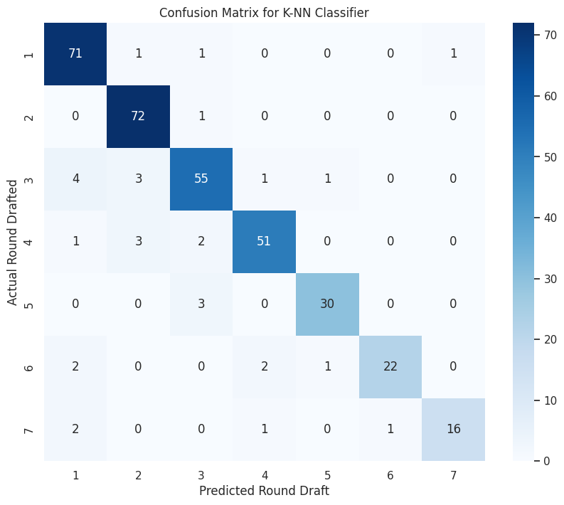

```python
import seaborn as sns
import matplotlib.pyplot as plt
from sklearn.metrics import confusion_matrix

# Create a confusion matrix
cm = confusion_matrix(y_test_knn, pred_knn)

# Plot the confusion matrix and utilize a heat map
plt.figure(figsize=(10, 8))

# Create custom labels ranging from 1 to 7 inclusive
labels = [str(i) for i in range(1, 8)]
sns.heatmap(cm, annot=True, fmt="d", cmap="Blues", xticklabels=labels, yticklabels=labels)
plt.xlabel('Predicted Round Draft')
plt.ylabel('Actual Round Drafted')
plt.title('Confusion Matrix for K-NN Classifier')
plt.show()
```

```python
for i in range(cm.shape[0]):
    true_positives = cm[i, i]
    total = sum(cm[:, i])
    accuracy = true_positives / total
    print(f"Accuracy for Round {i+1}: {accuracy:.2%}. {true_positives} out of {total}")
```

```
Accuracy for Round 1: 88.75%. 71 out of 80
Accuracy for Round 2: 91.14%. 72 out of 79
Accuracy for Round 3: 88.71%. 55 out of 62
Accuracy for Round 4: 92.73%. 51 out of 55
Accuracy for Round 5: 93.75%. 30 out of 32
Accuracy for Round 6: 95.65%. 22 out of 23
Accuracy for Round 7: 94.12%. 16 out of 17
```

**Let's Examine VERY Wrong Predictions**

As demonstrated in the output below three players' predicted draft round were off by a considerable margin. Let's explain why maybe this is the case:

1) **Eno Benjamin**: Predicted to go in the 1st round, Eno Benjamin was actually drafted in the 7th round. His 40-yard dash time was 4.57 which is standard for his position, right around average. However, his vertical jump was outstanding at 39 inches which is likely what carried his 1st round projection. Currently Eno Benjamin is upcoming on his 5th season, which is longer than the average NFL career. He has not produced at a 1st round level like predicted and more like a 7th rounder.  
**NFL General Managers were CORRECT**

2) **Sam Ehlinger**: Predicted to go in the 1st round, Sam Ehlinger was actually drafted in the 6th round. Similar to Eno Benjamin, Ehlinger's 40 time was average but his vertical jump was in the 95th percentile, which likely carried his 1st round projection. Currently Sam Ehlinger is a backup and has not played like a predicted 1st round talent.  
**NFL General Managers were CORRECT**

3) **Dustin Keller**: Predicted to go in the 7th round, Dustin Keller was actually drafted in the 1st round. Dustin Keller's vertical and 40 time were both average but was still selected in the 1st round in real life. Dustin Keller played 5 years for the New York Jets before retiring. His career did not live up to the 1st round expectations and instead played closer to the 7th round projection given by the model.  
**K-NN Model was more CORRECT**

```python
import pandas as pd

classifications = pd.DataFrame({
    "name": names_test,
    "predicted": pred_knn,
    "actual": y_test_knn
})
classifications = classifications.drop_duplicates(subset=["name"])

# Players that were predicted way too high
overclassified = classifications[(classifications['predicted'] == 1) & (classifications['actual'].isin([6, 7]))]
print(overclassified)

# Players that were predicted way too low
underclassified = classifications[(classifications['predicted'].isin([6,7])) & (classifications['actual'] == 1)]
print(underclassified)
```

```
              name  predicted  actual
2202  Eno Benjamin        1.0     7.0
5276  Sam Ehlinger        1.0     6.0
               name  predicted  actual
2107  Dustin Keller        7.0     1.0
```

**Why are these results the case?**

The results were better than anticipated and slightly better than the Random Forest Classifier. All the input features are very relevant to draft position and something very NFL General Manager pays attention to. Although the number of inputs is minimal, the model still found patterns within the data and was able to do a great job of predicting the round. KNN also doesn't suffer from the curse of dimensionality in this case, where all inputs are weighted equally. Since these inputs are all very important and there are not much less important features, the model performs well.

**Conclusions Drawn**

In a scenario like this when the number of inputs is low a K-NN model will generally perform better due to its ability to find patterns with low dimensionality. This being said, both models performed extremely well - better than my original estimate. Both models would've likely performed better if other inputs such as height, college production, bench press reps, and 3-cone drill times were also included. I could see the random forest classifier overtaking the KNN model in accuracy if these inputs were also included.

# Hypothesis #3

**Null Hypothesis**: Running backs that have spent 4 or less years in the NFL have a similar distribution of rushing yards (in a season) as those that have spent 5 or more years in the NFL

**Alternate Hypothesis**: Running backs that have spent 4 or less years in the NFL do not have similar distribution of rushing yards (in a season) as those that have spent 5 or more years in the NFL

**Why did we use a two-sample t-test?**  
Since two independent groups and two continous variables are being compared a two-sample t-test should be used to determine if there is a significant difference in the means of the two groups.

```python
young_rbs = rb_room[rb_room["years_played"] <= 4]
veteran_rbs = rb_room[rb_room["years_played"] >= 5]

# Since two independent groups and two continous variables are being compared a
# two-sample t-test should be used to determine if there is a signficant
# difference in the means of the two groups

_, p = ttest_ind(young_rbs["rushing_yards"], veteran_rbs["rushing_yards"])
print(f"P-value:", p)

print(f"There are {len(young_rbs)} young running backs in the NFL. The average rushing yards in a season for a young running back is {young_rbs.loc[:, 'rushing_yards'].mean()}")
print(f"There are {len(veteran_rbs)} veteran running backs in the NFL. The average rushing yards in a season for a veteran running back is {veteran_rbs.loc[:, 'rushing_yards'].mean()}")
```

```
P-value: 7.323179107479421e-17
There are 471 young running backs in the NFL. The average rushing yards in a season for a young running back is 335.30785562632695
There are 251 veteran running backs in the NFL. The average rushing yards in a season for a veteran running back is 587.8565737051792
```

**Conclusions:**  
Since the p-value is extremely small (very close to 0) and less than than the alpha value (0.05) the null hypothesis is rejected and we are able to conclude that running backs that have spent 4 or less years in the NFL do not have a similar mean of rushing yards in a season compared to those that have spent 5 or more years in the NFL

**Why is this the case?**  
For starters, the league provides a higher base salary for veterans (those with more than 4 accrued years in the NFL) compared to those with 4 or less accrued years. Teams have a higher propensity to keep a non-veteran runningback compared to a veteran runningback due to differences in salary. Veteran runningbacks are typically only on a team if they are high performing, otherwise if they have a history of not rushing for very many yards or only contribute on special teams, that role can easily be replaced by a younger running back. Running back is known as one of the most replaceable positions in the league. As a result there are nearly twice as many non-veteran running backs (471) as veteran running backs (251). As demonstrated in the swarm plot below, while there are many high performing non-veteran runningbacks, there is a high concentration of runningbacks in their 1st to 4th year with close to 0 rushing yards on the season.

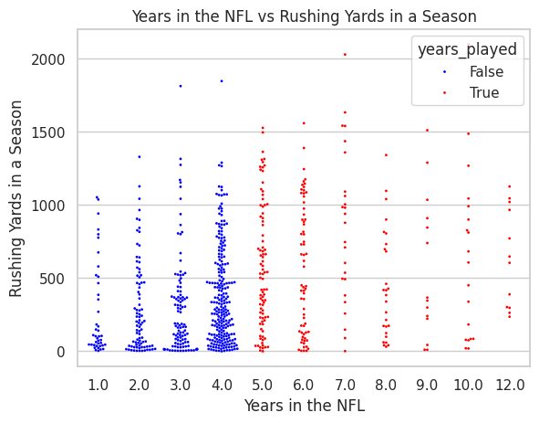

```python
import seaborn as sns

# Swarm Plot that displays the # of years in NFL vs. # of rushing yards and their estimatable frequency
# Veterans in Red, young players in blue
sns.swarmplot(x="years_played", y="rushing_yards", data=rb_room, hue=rb_room['years_played'] >= 5, palette=["blue", "red"], size = 2)

plt.title('Years in the NFL vs Rushing Yards in a Season')
plt.xlabel('Years in the NFL')
plt.ylabel('Rushing Yards in a Season')
```

**Implement ML Techniques to Reveal What Contributes to Running back Rushing Yardage and Predict Future Performance**

Through the utilization of Principal Component Analysis (PCA) we will reduce dimensionality to extract inputs that account for the greatest amount of variation in a running back's season yardage. Then use TensorFlow/Keras to predict the performance of Running Backs.

```python
from sklearn.preprocessing import StandardScaler
from sklearn.decomposition import PCA

rb_data = yearly_df[yearly_df["position"] == "RB"]
features = ["years_played", "games", "carries", "offense_snaps", "overall"]
rb_data = rb_data.dropna(subset = features)
feature_data = rb_data[features]
feature_data = feature_data.dropna(subset = features)

scaler = StandardScaler()
features_scaled = scaler.fit_transform(feature_data)

pca = PCA(n_components = 3)
components = pca.fit_transform(features_scaled)

variance = pca.explained_variance_ratio_
print(f"The 1st Principal Component captures {variance[0]:.2%} of the variance")
print(f"The 2nd Principal Component captures {variance[1]:.2%} of the variance")
print(f"The 3rd Principal Component captures {variance[2]:.2%} of the variance")
print(f"The first three Principal Components capture {(variance[0] + variance[1] + variance[2]):.2%} of the variance")
```

```
The 1st Principal Component captures 56.90% of the variance
The 2nd Principal Component captures 21.00% of the variance
The 3rd Principal Component captures 13.24% of the variance
The first three Principal Components capture 91.13% of the variance
```

In Principal Component Analysis the 1st PC will capture most of the variance, the 2nd PC will capture the second most, and so on. As a result most of the variance can be captured in only the first three components. Below I will print how each original target feature contributes to each component

```python
for i, comp in enumerate(pca.components_):
    print(f"Component {i+1}:")
    component_contributions = zip(features, comp)
    sorted_contributions = sorted(component_contributions, key=lambda x: abs(x[1]), reverse=True)
    for feature, contribution in sorted_contributions:
        print(f"{feature}: {contribution:.2f}")
    print("\n")
```

```
Component 1:
carries: 0.55
offense_snaps: 0.54
games: 0.49
overall: -0.35
years_played: 0.20


Component 2:
years_played: 0.81
overall: -0.43
games: -0.33
offense_snaps: -0.16
carries: -0.12


Component 3:
overall: 0.82
years_played: 0.53
offense_snaps: 0.17
games: 0.14
carries: 0.04
```

**What Does PCA Reveal?**

**Component 1:** Reflects player utilization in games. How often they are in the game and touch the ball is highly correlated with the number of rushing yards they have in a season as demonstrated by high positive weights

**Component 2:** Reflects experience of a player. Indicates that the number of years a player has been in the NFL has a strong influence on this component demonstrated by 0.81 weight associated with years_played.

**Component 3:** Reflects draft position (overall draft position) in this component as well as again, the number of years a player has played in the NFL.

**Use TensorFlow/Keras to build a Neural Network**

Experience and knowledge of TensorFlow/Keras comes from taking CMSC421 and personal experience in projects.

```python
import tensorflow as tf
from sklearn.metrics import mean_absolute_error

X_train, X_test, y_train, y_test = train_test_split(components, rb_data["rushing_yards"], test_size=0.2, random_state=42)

model = tf.keras.Sequential([
    tf.keras.layers.Dense(10, activation='relu', input_shape=(X_train.shape[1],)),
    tf.keras.layers.Dense(1, activation='linear')
])

model.compile(optimizer=tf.keras.optimizers.Adam(learning_rate=0.001),
              loss='mean_absolute_error')

model.fit(X_train, y_train, epochs=150, batch_size=10, verbose=0)

test_loss = model.evaluate(X_test, y_test, verbose=0)
print(f'Test loss Mean Absolute Error: {test_loss}')

predictions = model.predict(X_test)

mse = mean_absolute_error(y_test, predictions)
print(f'Mean Absolute Error on Test set: {mse}')
```

```
Test loss Mean Absolute Error: 126.26048278808594
Mean Absolute Error on Test set: 126.26048282585522
```

**How did the Model Perform?**

The Mean Absolute Error on the Test set was relatively low at about 127 yards. This is means that the neural network is a pretty good predictor of a running back's season rushing total based on a number of input features. It also demonstrates the effectiveness of Principal Component Analysis which sucessfully reduced dimensionality but maintained a relatively high accuracy when used in the neural network.

**Why use Mean Absolute Error?**  
I chose to use Mean Absolute Error on the Test set because rushing yardage can be quite high, and a number like 127 is much easier to interpret compared to a squared number (like with MSE) such as 16129 which generally doesn't mean a whole lot.

**Overall Conclusions**  
Although the dataset is somewhat small, the neural network did a fantastic job at detecting patterns in the Principal Components and would've outperformed a different ML model such as a Random Forest Regressor or Decision Tree. Principal Component Analysis is also very effective in transforming the key inputs that affect variation while also reducing dimensionality.

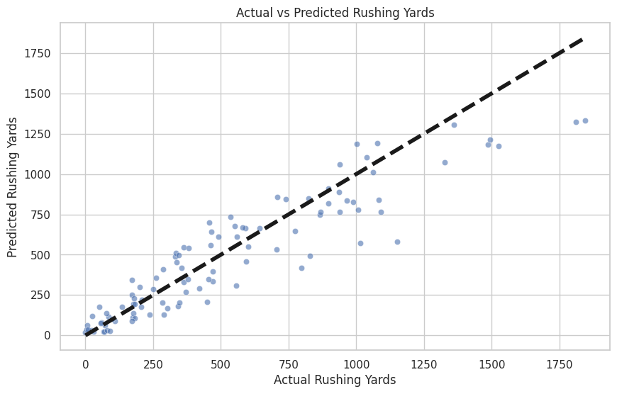

```python
import matplotlib.pyplot as plt
import seaborn as sns

# Flatten predictions
predictions = predictions.flatten()

sns.set(style="whitegrid")
plt.figure(figsize=(10, 6))
sns.scatterplot(x=y_test, y=predictions, alpha=0.6)
plt.plot([y_test.min(), y_test.max()], [y_test.min(), y_test.max()], 'k--', lw=4)
plt.title('Actual vs Predicted Rushing Yards')
plt.xlabel('Actual Rushing Yards')
plt.ylabel('Predicted Rushing Yards')
plt.show()
```

# **Final Conclusions**

We originally chose to explore NFL offensive data from 2012 to 2022 to improve out data science skills and reveal trends in the data not is not otherwise obvious. We also strived to answer the following questions:

1) **How does the number of years played affect the number of receiving yards by a wide receiver?**  
2) **How do combine measurables such as speed and vertical jump translate to NFL success and draft position?**  
3) **What factors are most important when determining how many yards a running back rushed for? Does age play a large role?**

Through our analysis of the data we been able to answer these questions and given signficant analysis and conclusions above as well. We have vastly improved our data preprocessing, visualization, machine learning, and result analysis skills through this project. I have answered the questions above in a quick sentence below - more detail in answering these questions can be found in the conclusions and data visualizations demonstrated above.

1) There is evidence to support a moderate positive linear relationship between the number of years played and the number of receiving yards by a wide receiver

2) Speed, weight, and vertical jump all play signficant roles on where an offensive player is drafted. However, speed does NOT play a signficant role in determining the success of a quarterback measured in passing yards per game.

3) Carries, touches, draft position, and age are all important factors when determining how many yards a running back will rush for in a season. Typically a veteran running back will rush for more yards than a non-veteran running back.

**Thank you for exploring this data with us!**  
-**Ryne Acheson and Tyler Cariaga**